# Google Search Interests in Video Games during the COVID-19 lockdown in the US

2020-10-21

# Background

Stay-at-home orders for COVID-19 forced people to stay at home. Anecdotal and media reports suggested that people consumed more and more video games during the lockdown. Below, I will use the Google Trend Data for the topic Video Game in the US to visualize how the interests in video games increased during the lockdown compared with the previous years, and the number of states who declared a stay-at-home order.

# Method

```r
# Load Libraries
library(tidyverse)
library(lubridate)
library(gtrendsR)
library(here)

# API Code from GTrend
filename <- "Google Trend - Gaming.csv"
# Topics:
#   - Video Game (%2Fm%2F01mw1)
#   - Game (%2Fm%2F03bt1gh)

# Get the gtrend data
video_game_topic_id <- "%2Fm%2F01mw1"
video_game_gtrend <- gtrends(keyword = video_game_topic_id,
                             onlyInterest = TRUE, geo = "US")

# Get a tibble from gtrend list
video_game_gtrend_interests <- video_game_gtrend[["interest_over_time"]] %>%
    as_tibble() %>%
  filter(year(date) %in% 2016:2020)

# Save out as a CSV
write_csv(video_game_gtrend_interests, here("static/data/video_game_gtrend.csv"))

# Load stay-at-home data from Wikipedia
stay_home_dates <- read_csv(here("static/data/wikipedia.csv"),
                            col_types = list()) # load with auto col types
# Get the df showing how many states are stay-at-home at an given date
stayathome_df <- stay_home_dates %>%
  select(-Stateofemergencydeclared) %>%
  pivot_longer(c(Stayathomeordered, Datelifted),
               values_to = "date", names_to = "Event") %>%
  arrange(date) %>%
  mutate(weight = case_when(Event == "Stayathomeordered" & is.na(date) == FALSE ~ 1,
                            Event == "Datelifted" & is.na(date) == FALSE ~ -1)) %>%
  mutate(n_stayathome = cumsum(weight)) %>%
  # When multiple states declare stay-at-home, we want to sum the number
  group_by(date) %>% slice_tail() %>%
  # We only need date and n_stayathome
  select(date, n_stayathome)

## Combine the stayathome df with the google, fill downward
vg_home_df <- video_game_gtrend_interests %>%
  full_join(stayathome_df, by = "date") %>%
  drop_na(date) %>%
  arrange(date) %>%
  fill(n_stayathome, .direction = "down") %>%
  mutate(plot_date = as_datetime("2020-1-1") + days(yday(date)),
         plot_date_stayathome = case_when(!is.na(n_stayathome) ~ plot_date),
         plot_date_hits = case_when(!is.na(hits) ~ plot_date))
```

I used data from [Google Trend Scores](https://trends.google.com/). I chose the topic `Video Game` (Topic ID: `%2Fm%2F01mw1`, rather than using a specific search term, to get the overall search interests in this topic. The data included the Google Trend scores from 2016-01-03 to 2020-10-18. I downloaded data using the `gtrendsR::gtrends()` function.

To get the number of states that were under a stay-at-home order, I used the table from the Wikipedia entry, [“U.S. state and local government responses to the COVID-19 pandemic”](https://en.wikipedia.org/wiki/U.S._state_and_local_government_responses_to_the_COVID-19_pandemic). I had to do some manual cleaning on this. The file is available as `wikipedia.csv` in the data folder.

# Results

The plot shows the Google Trend Scores for the topic `Video Game` on the y-axis. The x-axis represents months of a year. The colored lines represent the years. The gray line represents the number of stats on a stay-at-home order on a given date in 2020.

The upward spikes of the Google Trend Scores seem to correspond with the upward spike of the number of stay-at-home order states (Mid-March to April). Both the Google Trend Scores and the number of stay-at-home order states remained high until May. Then, the interest in video games seems to take on a decreasing trend as some states started to reopen, while they remain higher than those in the pre-COVID years.

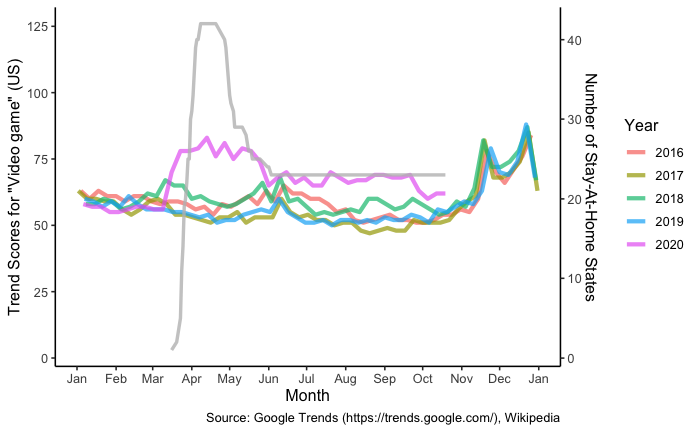

```r
# Plot
vg_home_df %>%
  # the x-axis is the day of the year. Set year to 2020 for plotting
  # yday() gets the order of the date in a given year. days() converts the integer to interval obj
  # adding them up gives the hypothetical day of the year for plotting
  ggplot(aes(y = hits,
             group = factor(year(date)),
             color = factor(year(date)))) +
  # Line for the gtrend scores
  geom_line(aes(x = plot_date_hits), size = 1.5, alpha = .7, na.rm = TRUE)  +
  # Line for the stay-at-home order
  geom_line(aes(x = plot_date_stayathome,y = n_stayathome*sec_axis_scaling, color = NULL),
            color = "gray", size = 1.2, alpha = .8, na.rm = TRUE) +
  # Labels
  #   Y-axis
  ylab("Trend Scores for \"Video game\" (US)") +
  #   Second Y-axis
  scale_y_continuous(sec.axis = sec_axis(~./sec_axis_scaling,
                                         name = "Number of Stay-At-Home States")) +
  #   X-axis
  scale_x_datetime(date_labels = "%b", name = "Month", date_breaks = "1 month") +
  #   Caption
  labs(caption = "Source: Google Trends (https://trends.google.com/), Wikipedia") +
  #   Legend Title
  scale_color_discrete(name = "Year") +
  # Theme
  theme_classic(base_size = 12)
```

# Conclusion

Search interests in video games seemed to have spiked up during the stay-at-home orders in the US, compared with the trends in the previous years.